# Test survival analysis

Eric Ménétré

24/07/2020

## Interpretation of the graphical results

Non-epileptic patients seem to need more time to reach their final diagnosis. This finding can be explained by the fact that patients arriving to the ED for a suspition of first epileptic seizure were investigated for epilepsy and exclude this diagnosis took time. Regarding the relapses, the delay until the final diagnosis seems to be crucial for non-epileptic patients while the effect is much weaker for epileptic patients. However, that is not a conclusive proof that a swift intervention is beneficial. The effect can be carried by difficult cases which take more time to be diagnosed. Indeed, at 0 day, arround 40% of patients who will relapse don’t have their final diagnosis, compared to 20% for seizure-free patients.To overcome this problem, we might want to look at the delay between the first seizure and the first consultation by an epileptologist. Results show that epileptic patients tend to be seen in consultation by an epileptologist later than a non-epileptic patients (in median 8.5 days). The only way I see to explain that is that epileptic patients are often seen in the ED, the diagnosis and treatment are settled, which means that it is less urgent to see them compared to a non-epileptic patient for whom the diagnosis is still uncertain. Regarding relapses, the delay between the first event and the first consultation does not seem to impact relapses in epileptic patients. It might be possible that this delay was not relevant since number of patients are already treated in the ED, making the delay until the appointement with an epileptologist less relevant. Maybe the key variable is the delay between the first seizure and the day an AED was initiated. Results show that there is no impact of this delay. An explanation might be that doctors in the ED target correctly the patients who need to be treated immediately and those who don’t, cancelling the effect of delay. Patients with high risk of relapse are treated right away, while patients with a low relapse risk are treated later. Unfortunately, this hypothesis cannot be tested, since it would involve to randomly treat patients in different delays, which is not very ethical… In conclusion, there is probably no way to answer this question with these data.

# data importation and transformation

# Survival plot

## Delay to the final diagnosis between epileptic and non-epileptic patients

This plot looks at the differences in **delay to reach the final diagnosis** between **epileptic** and **non-epileptic patients**.

Graphically, it seems that non-epileptic patients tend to reach their diagnosis later than epileptic patients –> Probably because the patients comes to the ER, where a first seizure is suspected and it takes time to rule out epilepsy. Another explanation could be that since the epilepsy-like event are less life threatning, it is less urgent to investigate (often syncopes).

```
## Call: survfit(formula = Surv(delay_dx_final, censored) ~ dx.dicho,
##     data = data_surv)
##
##    3 observations deleted due to missingness
##              n events median 0.95LCL 0.95UCL
## dx.dicho=1 417    417      0       0       0
## dx.dicho=2 295    289      1       0       2
```

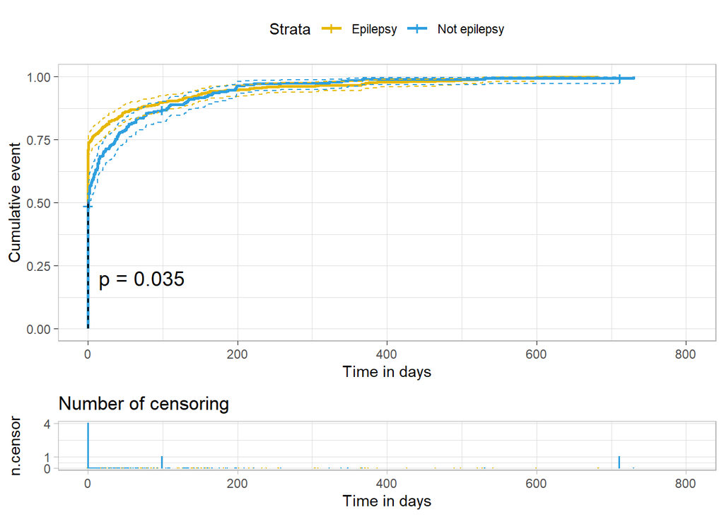

```
## Call:
## survdiff(formula = Surv(delay_dx_final, censored) ~ dx.dicho +
##     relapses, data = data_surv)
##
## n=712, 3 observations deleted due to missingness.
##
##                          N Observed Expected (O-E)^2/E (O-E)^2/V
## dx.dicho=1, relapses=1 302      302    252.7    9.6116    27.254
## dx.dicho=1, relapses=2 115      115    142.8    5.4041    10.769
## dx.dicho=2, relapses=1 243      240    236.1    0.0642     0.164
## dx.dicho=2, relapses=2  52       49     74.4    8.6726    14.066
##
##  Chisq= 40.6  on 3 degrees of freedom, p= 8e-09
```

## Delay to the final diagnosis between epileptic and non-epileptic patients and adding the relapses information

Same model as before but adding the **relapses information**.

By adding the relapse information, it appears that the patients who relapse tend to recieve their diagnosis later than those who don’t. The effect mignt be explained by the difficulty to diagnose some patients. Patients who are hard to diagnose have more relapses until we are sure about the diagnosis and start a treatment. To see the real effect of the delay, it might be more appropriate to use another variable, such as the **delay until the first consultation**, in order to avoid the effect of difficulty to diagnose patients.

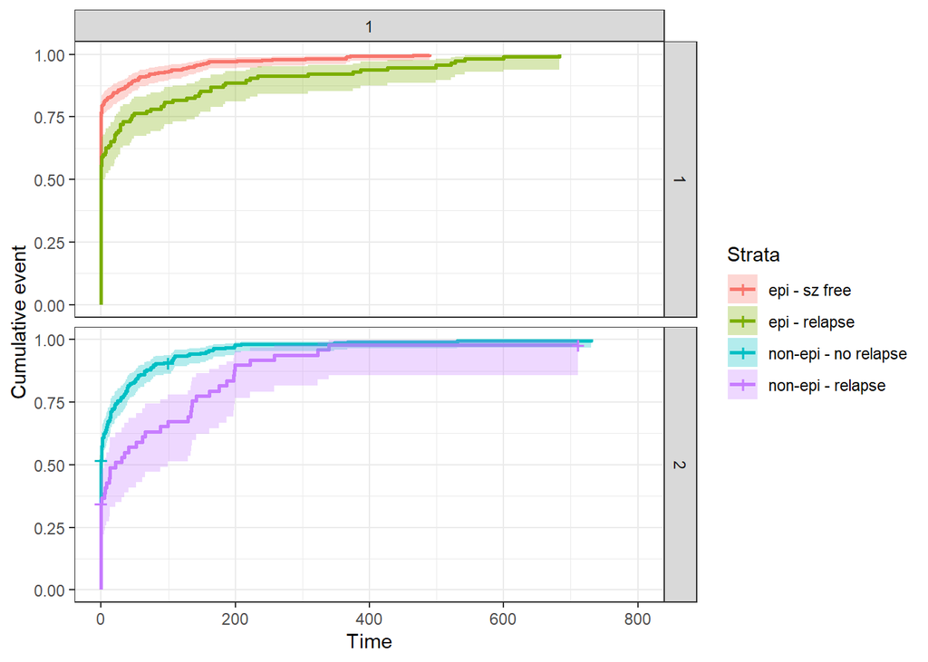

## Delay between the first seizure and the first consultation by an epileptologist, between epileptic and non-epileptic patients

It seems that non-epileptic patients are seen in priority compared to epileptic patients. this counter intuitive result might be explained by the fact that easy epileptic cases are usually seen and treated in the ED, implying that the follow-up is not so urgent. However, for non-epileptic patients, there still might be a doubt on the diagnosis.

```
## Call: survfit(formula = Surv(delay_cs_epi, censored) ~ dx.dicho, data = data_surv_cs)
##
##    27 observations deleted due to missingness
##              n events median 0.95LCL 0.95UCL
## dx.dicho=1 297    297     40      35      45
## dx.dicho=2 190    148     31      26      39
```

```
##            records n.max n.start events   *rmean *se(rmean) median 0.95LCL
## dx.dicho=1     297   297     297    297 73.87205   5.657168     40      35
## dx.dicho=2     190   190     190    148 52.20352   5.709449     31      26
##            0.95UCL
## dx.dicho=1      45
## dx.dicho=2      39
```

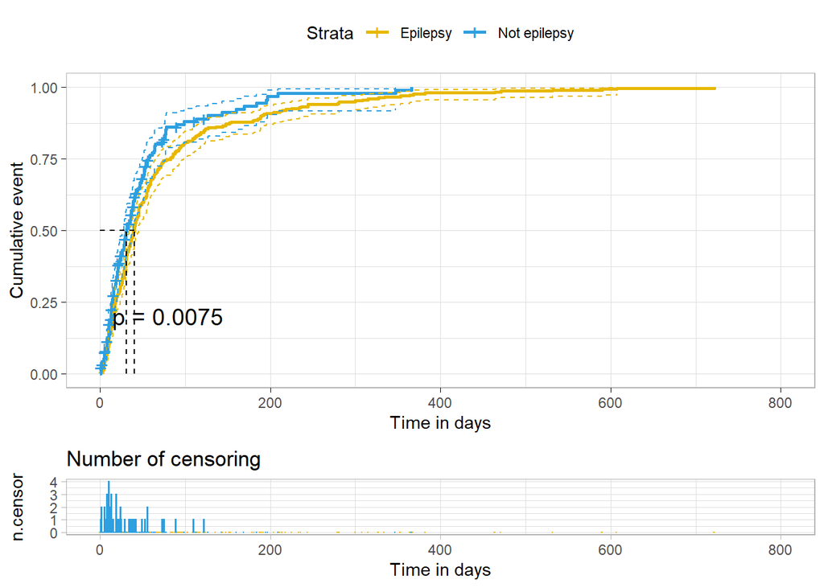

[output not shown]

The data were verified, non-epileptic patients are seen in median a few days before non-epileptic patients

```
## # A tibble: 2 x 4
##   dx.dicho mean_delay    median_delay max_delay
##   <chr>    <drtn>        <drtn>       <drtn>
## 1 epi      27.44000 days 27.5 days    59 days
## 2 non-epi  22.76374 days 19.0 days    58 days
```

## Delay between the first seizure and the first consultation between epileptic and non epileptic patients and adding the relapse information.

There does not seems to be an effect according to the delay for the epileptic patients but a tendency appears for the non-epileptic patients.

[output not shown]

No effect, probably because patients are treated in the ED. Let’s try with treatment delay.

```
## Call: survfit(formula = Surv(delay_cs_epi, censored) ~ relapses, data = data_surv_cs_epi)
##
##              n events median 0.95LCL 0.95UCL
## relapses=1 186    186   39.5      34      47
## relapses=2 111    111   41.0      30      47
```

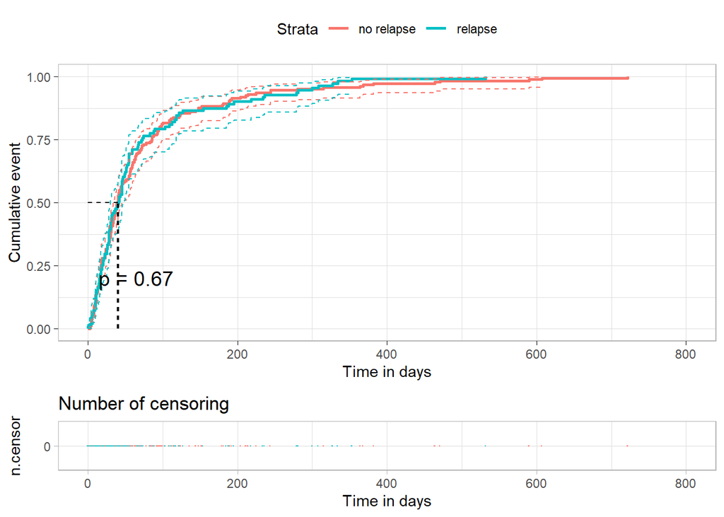

## Delay between the first seizure and the instauration of an AED between patients who relapse or not

The delay between the first seizure and the instauration of treatment does not seems to impact the presence of relapses. Probably because patients who absolutely need a treatment are already treated in the ED.

[output not shown]

```
##            records n.max n.start events   *rmean *se(rmean) median 0.95LCL
## relapses=1     165   165     165    165 91.03636   11.01647     40      37
## relapses=2      99    99      99     99 79.71717   11.44265     42      30
##            0.95UCL
## relapses=1      56
## relapses=2      49
```

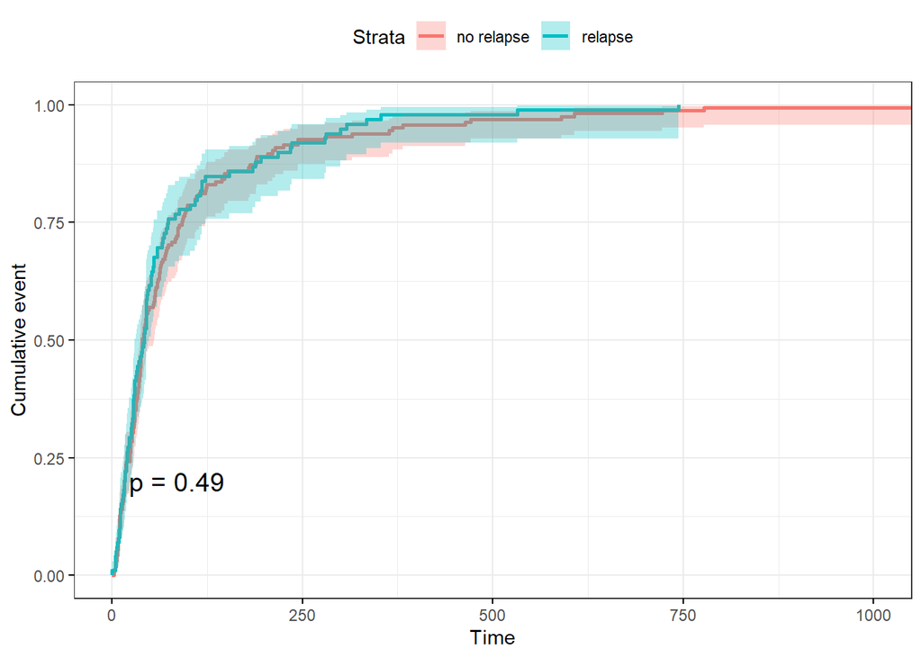